# Continuous Integration Smell Report

Wed Aug 15 11:20:19 2018

### Project: AxonFramework/AxonFramework

### Slow builds

### Broken release branch

### Skip failed tests

### Aged branches

## Slow builds

### → Stable -

### During the last 90 days, your build duration is increasing of 1.15%

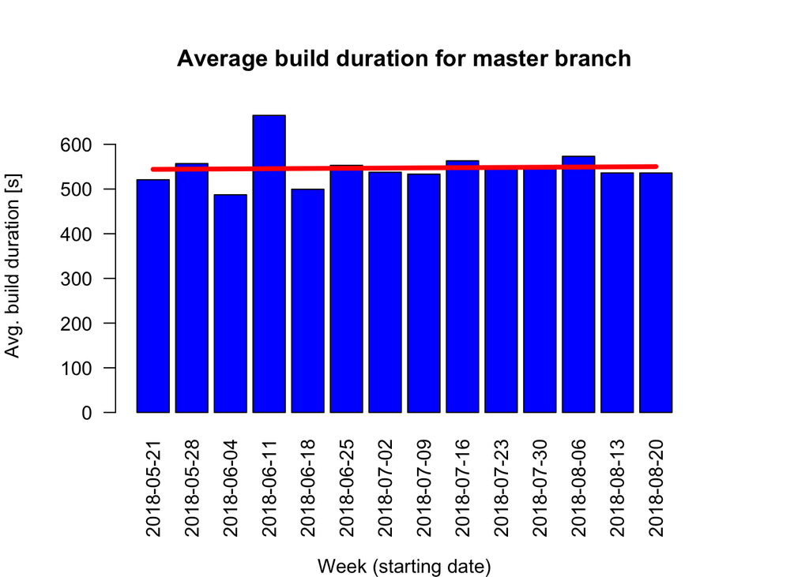

## Broken release branch

### ↘ Downtrend -

### Downtrend: during the last 90 days, the number of broken release builds is decreasing of 66.97%

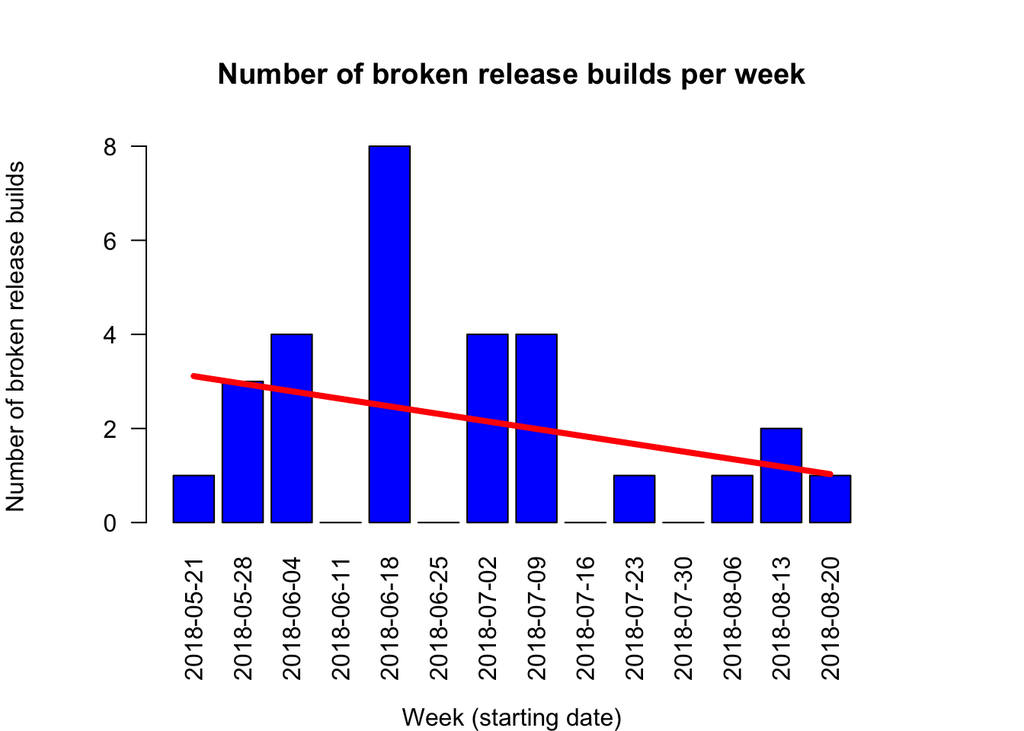

### During the last 90 days your master was broken 29 times, with an average breakage duration of 19290s (~5.36 hours)

## Skip failed tests

(show more)

### Instead of making a fix when a test failed, we found, over the last 6 months, 3 builds in which at least one test has been skipped/ignored

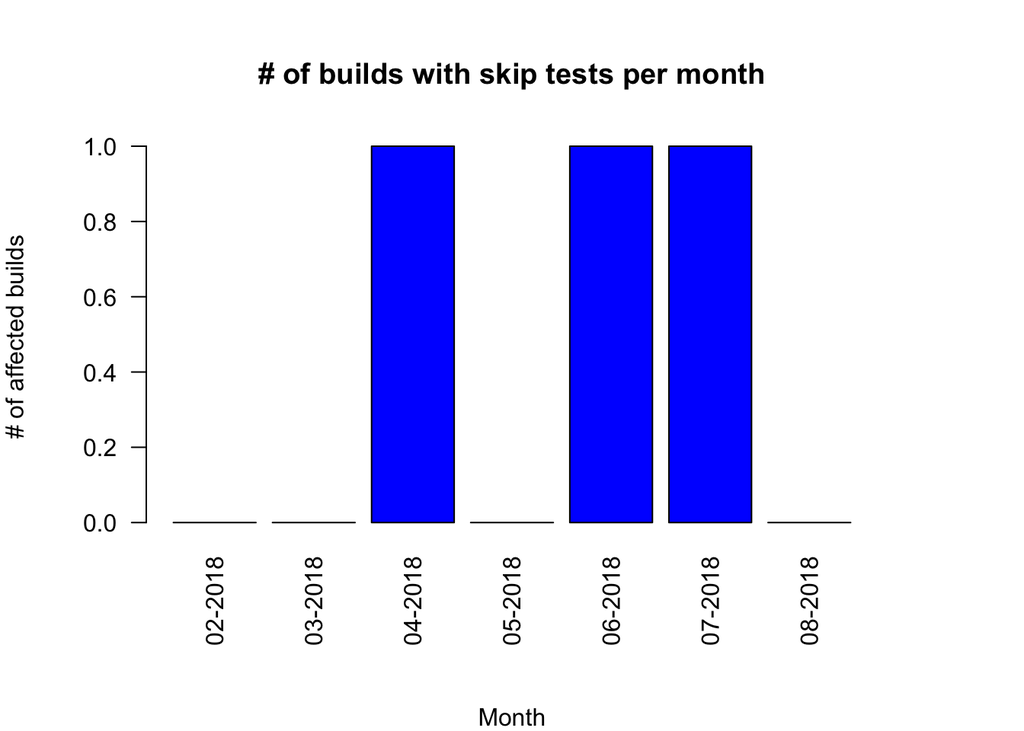

(show more)

### Skip test has occurred in the following builds:

| Date | Build | SkippedTests |
| --- | --- | --- |
| 2018-07-18 21:36:49 | 405555718 | org.axonframework.queryhandling.DefaultQueryGatewayTest |
| 2018-06-12 15:24:50 | 391321989 | org.axonframework.deadline.QuartzDeadlineManagerTest org.axonframework.deadline.SimpleDeadlineManagerTest |
| 2018-04-18 10:15:34 | 368073733 | org.axonframework.spring.config.SpringAxonAutoConfigurerTest |

## Aged branches

##### Issues found for branch: aggregate-lifecycle-version

- High severity: In your project, branches are typically synced with master every 164909s (~1.91 days). However, branch aggregate-lifecycle-version has last synced with master on 2018-03-20 12:37:00. and branch master has commits that are 4877269s (~8.06 weeks) newer than that.
- High severity: Your latest commits were performed on branch feature/687-EventProcessingConfiguration-BiFunction on 2018-08-13 14:12:49. However, your last changes on branch aggregate-lifecycle-version happened 12372249s (~20.46 weeks) ago, and have not been merged yet. In your project, you typically merge branches within 3616145s (~5.98 weeks).
- High severity: In your project, branches do not deviate for more than 4829458s (~7.99 weeks). However, you are working on branch aggregate-lifecycle-version since 12616549s (~20.86 weeks) without synchronization.

##### Issues found for branch: axon-3.0.x

- High severity: In your project, branches are typically synced with master every 164909s (~1.91 days). However, branch axon-3.0.x has last synced with master on 2018-02-07 07:53:56. and branch master has commits that are 8436653s (~13.95 weeks) newer than that.
- High severity: In your project, branches do not deviate for more than 4829458s (~7.99 weeks). However, you are working on branch axon-3.0.x since 16175933s (~26.75 weeks) without synchronization.
- High severity: You have been working on axon-3.0.x for 10712269s (~17.71 weeks).Your feature branches are typically open for 164909s (~1.91 days).

##### Issues found for branch: axon-3.1.2

- High severity: In your project, branches are typically synced with master every 164909s (~1.91 days). However, branch axon-3.1.2 has last synced with master on 2018-01-12 14:23:15. and branch master has commits that are 10659694s (~17.63 weeks) newer than that.
- High severity: Your latest commits were performed on branch feature/687-EventProcessingConfiguration-BiFunction on 2018-08-13 14:12:49. However, your last changes on branch axon-3.1.2 happened 18402574s (~30.43 weeks) ago, and have not been merged yet. In your project, you typically merge branches within 3616145s (~5.98 weeks).
- High severity: In your project, branches do not deviate for more than 4829458s (~7.99 weeks). However, you are working on branch axon-3.1.2 since 18398974s (~30.42 weeks) without synchronization.

##### Issues found for branch: axon-3.1.3

- High severity: In your project, branches are typically synced with master every 164909s (~1.91 days). However, branch axon-3.1.3 has last synced with master on 2018-02-26 23:05:05. and branch master has commits that are 6740384s (~11.14 weeks) newer than that.
- High severity: Your latest commits were performed on branch feature/687-EventProcessingConfiguration-BiFunction on 2018-08-13 14:12:49. However, your last changes on branch axon-3.1.3 happened 14483264s (~23.95 weeks) ago, and have not been merged yet. In your project, you typically merge branches within 3616145s (~5.98 weeks).
- High severity: In your project, branches do not deviate for more than 4829458s (~7.99 weeks). However, you are working on branch axon-3.1.3 since 14479664s (~23.94 weeks) without synchronization.

##### Issues found for branch: axon-3.2

- High severity: In your project, branches are typically synced with master every 164909s (~1.91 days). However, branch axon-3.2 has last synced with master on 2018-03-13 22:25:00. and branch master has commits that are 5446789s (~9.01 weeks) newer than that.
- High severity: Your latest commits were performed on branch feature/687-EventProcessingConfiguration-BiFunction on 2018-08-13 14:12:49. However, your last changes on branch axon-3.2 happened 13189669s (~21.81 weeks) ago, and have not been merged yet. In your project, you typically merge branches within 3616145s (~5.98 weeks).
- High severity: In your project, branches do not deviate for more than 4829458s (~7.99 weeks). However, you are working on branch axon-3.2 since 13186069s (~21.8 weeks) without synchronization.

##### Issues found for branch: axon-3.2.1

- Medium Severity: Your latest commits were performed on branch feature/687-EventProcessingConfiguration-BiFunction on 2018-08-13 14:12:49. However, your last changes on branch axon-3.2.1 happened 8820866s (~14.58 weeks) ago, and have not been merged yet. In your project, you typically merge branches within 3616145s (~5.98 weeks).
- Medium Severity: In your project, branches do not deviate for more than 4829458s (~7.99 weeks). However, you are working on branch axon-3.2.1 since 8820866s (~14.58 weeks) without synchronization.

##### Issues found for branch: bug/513

- High severity: In your project, branches are typically synced with master every 164909s (~1.91 days). However, branch bug/513 has last synced with master on 2018-02-23 10:03:41. and branch master has commits that are 7046468s (~11.65 weeks) newer than that.
- High severity: Your latest commits were performed on branch feature/687-EventProcessingConfiguration-BiFunction on 2018-08-13 14:12:49. However, your last changes on branch bug/513 happened 14774732s (~24.43 weeks) ago, and have not been merged yet. In your project, you typically merge branches within 3616145s (~5.98 weeks).
- High severity: In your project, branches do not deviate for more than 4829458s (~7.99 weeks). However, you are working on branch bug/513 since 14785748s (~24.45 weeks) without synchronization.

##### Issues found for branch: bug/589

- Medium Severity: Your latest commits were performed on branch feature/687-EventProcessingConfiguration-BiFunction on 2018-08-13 14:12:49. However, your last changes on branch bug/589 happened 7707826s (~12.74 weeks) ago, and have not been merged yet. In your project, you typically merge branches within 3616145s (~5.98 weeks).

##### Issues found for branch: bugfix/591

- Medium Severity: Your latest commits were performed on branch feature/687-EventProcessingConfiguration-BiFunction on 2018-08-13 14:12:49. However, your last changes on branch bugfix/591 happened 7852504s (~12.98 weeks) ago, and have not been merged yet. In your project, you typically merge branches within 3616145s (~5.98 weeks).

##### Issues found for branch: command-handler-interceptor

- High severity: In your project, branches are typically synced with master every 164909s (~1.91 days). However, branch command-handler-interceptor has last synced with master on 2018-04-10 07:14:05. and branch master has commits that are 3082244s (~5.1 weeks) newer than that.
- High severity: Your latest commits were performed on branch feature/687-EventProcessingConfiguration-BiFunction on 2018-08-13 14:12:49. However, your last changes on branch command-handler-interceptor happened 10740576s (~17.76 weeks) ago, and have not been merged yet. In your project, you typically merge branches within 3616145s (~5.98 weeks).
- Medium Severity: In your project, branches do not deviate for more than 4829458s (~7.99 weeks). However, you are working on branch command-handler-interceptor since 10825124s (~17.9 weeks) without synchronization.

##### Issues found for branch: deadline-api

- High severity: You have been working on deadline-api for 4664946s (~7.71 weeks).Your feature branches are typically open for 164909s (~1.91 days).

##### Issues found for branch: event-upcasters-autoconfig

- Medium Severity: Your latest commits were performed on branch feature/687-EventProcessingConfiguration-BiFunction on 2018-08-13 14:12:49. However, your last changes on branch event-upcasters-autoconfig happened 8130351s (~13.44 weeks) ago, and have not been merged yet. In your project, you typically merge branches within 3616145s (~5.98 weeks).

##### Issues found for branch: feature-381

- High severity: In your project, branches are typically synced with master every 164909s (~1.91 days). However, branch feature-381 has last synced with master on 2018-03-07 12:47:27. and branch master has commits that are 5999842s (~9.92 weeks) newer than that.
- High severity: Your latest commits were performed on branch feature/687-EventProcessingConfiguration-BiFunction on 2018-08-13 14:12:49. However, your last changes on branch feature-381 happened 13299009s (~21.99 weeks) ago, and have not been merged yet. In your project, you typically merge branches within 3616145s (~5.98 weeks).
- High severity: In your project, branches do not deviate for more than 4829458s (~7.99 weeks). However, you are working on branch feature-381 since 13739122s (~22.72 weeks) without synchronization.

##### Issues found for branch: feature-441-replay-api

- High severity: In your project, branches are typically synced with master every 164909s (~1.91 days). However, branch feature-441-replay-api has last synced with master on 2018-02-07 12:38:05. and branch master has commits that are 8419604s (~13.92 weeks) newer than that.
- High severity: Your latest commits were performed on branch feature/687-EventProcessingConfiguration-BiFunction on 2018-08-13 14:12:49. However, your last changes on branch feature-441-replay-api happened 15780220s (~26.09 weeks) ago, and have not been merged yet. In your project, you typically merge branches within 3616145s (~5.98 weeks).
- High severity: In your project, branches do not deviate for more than 4829458s (~7.99 weeks). However, you are working on branch feature-441-replay-api since 16158884s (~26.72 weeks) without synchronization.

##### Issues found for branch: feature/236

- High severity: In your project, branches are typically synced with master every 164909s (~1.91 days). However, branch feature/236 has last synced with master on 2018-03-11 15:16:10. and branch master has commits that are 5645319s (~9.33 weeks) newer than that.
- High severity: Your latest commits were performed on branch feature/687-EventProcessingConfiguration-BiFunction on 2018-08-13 14:12:49. However, your last changes on branch feature/236 happened 13296344s (~21.98 weeks) ago, and have not been merged yet. In your project, you typically merge branches within 3616145s (~5.98 weeks).
- High severity: In your project, branches do not deviate for more than 4829458s (~7.99 weeks). However, you are working on branch feature/236 since 13384599s (~22.13 weeks) without synchronization.

##### Issues found for branch: feature/463

- High severity: In your project, branches are typically synced with master every 164909s (~1.91 days). However, branch feature/463 has last synced with master on 2018-01-19 12:35:07. and branch master has commits that are 10061382s (~16.64 weeks) newer than that.
- High severity: Your latest commits were performed on branch feature/687-EventProcessingConfiguration-BiFunction on 2018-08-13 14:12:49. However, your last changes on branch feature/463 happened 14181496s (~23.45 weeks) ago, and have not been merged yet. In your project, you typically merge branches within 3616145s (~5.98 weeks).
- High severity: In your project, branches do not deviate for more than 4829458s (~7.99 weeks). However, you are working on branch feature/463 since 17800662s (~29.43 weeks) without synchronization.
- High severity: You have been working on feature/463 for 3622766s (~5.99 weeks).Your feature branches are typically open for 164909s (~1.91 days).

##### Issues found for branch: feature/488

- High severity: In your project, branches are typically synced with master every 164909s (~1.91 days). However, branch feature/488 has last synced with master on 2018-02-08 12:44:37. and branch master has commits that are 8332812s (~13.78 weeks) newer than that.
- High severity: Your latest commits were performed on branch feature/687-EventProcessingConfiguration-BiFunction on 2018-08-13 14:12:49. However, your last changes on branch feature/488 happened 13309831s (~22.01 weeks) ago, and have not been merged yet. In your project, you typically merge branches within 3616145s (~5.98 weeks).
- High severity: In your project, branches do not deviate for more than 4829458s (~7.99 weeks). However, you are working on branch feature/488 since 16072092s (~26.57 weeks) without synchronization.
- High severity: You have been working on feature/488 for 2765861s (~4.57 weeks).Your feature branches are typically open for 164909s (~1.91 days).

##### Issues found for branch: feature/500

- High severity: In your project, branches are typically synced with master every 164909s (~1.91 days). However, branch feature/500 has last synced with master on 2018-02-12 20:50:08. and branch master has commits that are 7958081s (~13.16 weeks) newer than that.
- High severity: Your latest commits were performed on branch feature/687-EventProcessingConfiguration-BiFunction on 2018-08-13 14:12:49. However, your last changes on branch feature/500 happened 15536052s (~25.69 weeks) ago, and have not been merged yet. In your project, you typically merge branches within 3616145s (~5.98 weeks).
- High severity: In your project, branches do not deviate for more than 4829458s (~7.99 weeks). However, you are working on branch feature/500 since 15697361s (~25.95 weeks) without synchronization.

##### Issues found for branch: feature/505

- High severity: In your project, branches are typically synced with master every 164909s (~1.91 days). However, branch feature/505 has last synced with master on 2018-02-14 16:06:02. and branch master has commits that are 7802327s (~12.9 weeks) newer than that.
- High severity: Your latest commits were performed on branch feature/687-EventProcessingConfiguration-BiFunction on 2018-08-13 14:12:49. However, your last changes on branch feature/505 happened 14950105s (~24.72 weeks) ago, and have not been merged yet. In your project, you typically merge branches within 3616145s (~5.98 weeks).
- High severity: In your project, branches do not deviate for more than 4829458s (~7.99 weeks). However, you are working on branch feature/505 since 15541607s (~25.7 weeks) without synchronization.

##### Issues found for branch: future-as-response-type-for-query-handlers

- Medium Severity: Your latest commits were performed on branch feature/687-EventProcessingConfiguration-BiFunction on 2018-08-13 14:12:49. However, your last changes on branch future-as-response-type-for-query-handlers happened 8662942s (~14.32 weeks) ago, and have not been merged yet. In your project, you typically merge branches within 3616145s (~5.98 weeks).
- Medium Severity: In your project, branches do not deviate for more than 4829458s (~7.99 weeks). However, you are working on branch future-as-response-type-for-query-handlers since 9428045s (~15.59 weeks) without synchronization.

##### Issues found for branch: handler-defs-in-configurer

- High severity: In your project, branches are typically synced with master every 164909s (~1.91 days). However, branch handler-defs-in-configurer has last synced with master on 2018-04-17 06:47:51. and branch master has commits that are 2479018s (~4.1 weeks) newer than that.
- Medium Severity: In your project, branches do not deviate for more than 4829458s (~7.99 weeks). However, you are working on branch handler-defs-in-configurer since 10221898s (~16.9 weeks) without synchronization.
- High severity: You have been working on handler-defs-in-configurer for 6071195s (~10.04 weeks).Your feature branches are typically open for 164909s (~1.91 days).

##### Issues found for branch: improved-config-on-command-target-resolvers

- Medium Severity: Your latest commits were performed on branch feature/687-EventProcessingConfiguration-BiFunction on 2018-08-13 14:12:49. However, your last changes on branch improved-config-on-command-target-resolvers happened 7787453s (~12.88 weeks) ago, and have not been merged yet. In your project, you typically merge branches within 3616145s (~5.98 weeks).

##### Issues found for branch: jdbc-auto-config-extended

- Medium Severity: Your latest commits were performed on branch feature/687-EventProcessingConfiguration-BiFunction on 2018-08-13 14:12:49. However, your last changes on branch jdbc-auto-config-extended happened 7618345s (~12.6 weeks) ago, and have not been merged yet. In your project, you typically merge branches within 3616145s (~5.98 weeks).

##### Issues found for branch: multiple-sagas-single-event-processor

- High severity: In your project, branches are typically synced with master every 164909s (~1.91 days). However, branch multiple-sagas-single-event-processor has last synced with master on 2018-04-13 10:45:46. and branch master has commits that are 2810343s (~4.65 weeks) newer than that.
- Medium Severity: In your project, branches do not deviate for more than 4829458s (~7.99 weeks). However, you are working on branch multiple-sagas-single-event-processor since 10553223s (~17.45 weeks) without synchronization.
- High severity: You have been working on multiple-sagas-single-event-processor for 4664924s (~7.71 weeks).Your feature branches are typically open for 164909s (~1.91 days).

##### Issues found for branch: spawning-new-aggregate

- High severity: In your project, branches are typically synced with master every 164909s (~1.91 days). However, branch spawning-new-aggregate has last synced with master on 2018-03-23 08:45:30. and branch master has commits that are 4631959s (~7.66 weeks) newer than that.
- High severity: In your project, branches do not deviate for more than 4829458s (~7.99 weeks). However, you are working on branch spawning-new-aggregate since 12371239s (~20.46 weeks) without synchronization.
- High severity: You have been working on spawning-new-aggregate for 7250275s (~11.99 weeks).Your feature branches are typically open for 164909s (~1.91 days).

##### Issues found for branch: subscription-query

- High severity: In your project, branches are typically synced with master every 164909s (~1.91 days). However, branch subscription-query has last synced with master on 2018-03-13 12:23:19. and branch master has commits that are 5482890s (~9.07 weeks) newer than that.
- High severity: In your project, branches do not deviate for more than 4829458s (~7.99 weeks). However, you are working on branch subscription-query since 13222170s (~21.86 weeks) without synchronization.
- High severity: You have been working on subscription-query for 9679557s (~16 weeks).Your feature branches are typically open for 164909s (~1.91 days).

##### Issues found for branch: subscription-query-basic-backpressure

- High severity: In your project, branches are typically synced with master every 164909s (~1.91 days). However, branch subscription-query-basic-backpressure has last synced with master on 2018-03-14 15:42:30. and branch master has commits that are 5384539s (~8.9 weeks) newer than that.
- Medium Severity: Your latest commits were performed on branch feature/687-EventProcessingConfiguration-BiFunction on 2018-08-13 14:12:49. However, your last changes on branch subscription-query-basic-backpressure happened 7538194s (~12.46 weeks) ago, and have not been merged yet. In your project, you typically merge branches within 3616145s (~5.98 weeks).
- High severity: In your project, branches do not deviate for more than 4829458s (~7.99 weeks). However, you are working on branch subscription-query-basic-backpressure since 13123819s (~21.7 weeks) without synchronization.
- High severity: You have been working on subscription-query-basic-backpressure for 5585625s (~9.24 weeks).Your feature branches are typically open for 164909s (~1.91 days).

##### Issues found for branch: subscription-query-emitter-list

- High severity: In your project, branches are typically synced with master every 164909s (~1.91 days). However, branch subscription-query-emitter-list has last synced with master on 2018-03-20 10:40:42. and branch master has commits that are 4884247s (~8.08 weeks) newer than that.
- High severity: Your latest commits were performed on branch feature/687-EventProcessingConfiguration-BiFunction on 2018-08-13 14:12:49. However, your last changes on branch subscription-query-emitter-list happened 12627127s (~20.88 weeks) ago, and have not been merged yet. In your project, you typically merge branches within 3616145s (~5.98 weeks).
- High severity: In your project, branches do not deviate for more than 4829458s (~7.99 weeks). However, you are working on branch subscription-query-emitter-list since 12623527s (~20.87 weeks) without synchronization.

##### Tip: Frequently synchronized branches are easier to integrate.

##### Tip: Break features into smaller tasks to finish them faster.